# Are blind people considered a part of scientific knowledge producers?: Accessibility report on top-10 SCIE journal systems using a tripartite evaluation approach

JooYoung Seo and Soyoung Choi

# Data Preprocessing

```r
# Load required packages.
library(tidyverse)
library(tidytext)
library(gt)
library(ezpickr)
library(BrailleR)
library(papaja)

# Import data.
df <- ezpickr::pick("data/wos-core_SCIE 2021-November-16.csv")
# Take a glance at df.
glimpse(df)
```

```
## Rows: 9,581
## Columns: 7
## $ `Journal title`             <chr> "2D MATERIALS", "3 BIOTECH", "3D PRINTING …
## $ ISSN                        <chr> "2053-1583", "2190-572X", "2329-7662", "16…
## $ eISSN                       <chr> "2053-1583", "2190-5738", "2329-7670", "16…
## $ `Publisher name`            <chr> "IOP PUBLISHING LTD", "SPRINGER HEIDELBERG…
## $ `Publisher address`         <chr> "TEMPLE CIRCUS, TEMPLE WAY, BRISTOL, ENGLA…
## $ Languages                   <chr> "English", "English", "English", "English"…
## $ `Web of Science Categories` <chr> "Materials Science, Multidisciplinary", "B…
```

```r
head(df)
```

| Journal title | ISSN | eISSN | Publisher name | Publisher address | Languages | Web of Science Categories |
| --- | --- | --- | --- | --- | --- | --- |
| 2D MATERIALS | 2053-1583 | 2053-1583 | IOP PUBLISHING LTD | TEMPLE CIRCUS, TEMPLE WAY, BRISTOL, ENGLAND, BS1 6BE | English | Materials Science, Multidisciplinary |
| 3 BIOTECH | 2190-572X | 2190-5738 | SPRINGER HEIDELBERG | TIERGARTENSTRASSE 17, HEIDELBERG, GERMANY, D-69121 | English | Biotechnology & Applied Microbiology |
| 3D PRINTING AND ADDITIVE MANUFACTURING | 2329-7662 | 2329-7670 | MARY ANN LIEBERT, INC | 140 HUGUENOT STREET, 3RD FL, NEW ROCHELLE, USA, NY, 10801 | English | Engineering, Manufacturing \| Materials Science, Multidisciplinary |
| 4OR-A QUARTERLY JOURNAL OF OPERATIONS RESEARCH | 1619-4500 | 1614-2411 | SPRINGER HEIDELBERG | TIERGARTENSTRASSE 17, HEIDELBERG, GERMANY, D-69121 | English | Operations Research & Management Science |
| AAPG BULLETIN | 0149-1423 | 1558-9153 | AMER ASSOC PETROLEUM GEOLOGIST | 1444 S BOULDER AVE, PO BOX 979, TULSA, USA, OK, 74119-3604 | English | Geosciences, Multidisciplinary |
| AAPS JOURNAL | 1550-7416 | 1550-7416 | SPRINGER | ONE NEW YORK PLAZA, SUITE 4600 , NEW YORK, United States, NY, 10004 | English | Pharmacology & Pharmacy |

```r
# Only include English data.
df_eng <- df %>%
  filter(Languages == "English")

# Take a glance at df_eng.
glimpse(df_eng)
```

```
## Rows: 8,477
## Columns: 7
## $ `Journal title`             <chr> "2D MATERIALS", "3 BIOTECH", "3D PRINTING …
## $ ISSN                        <chr> "2053-1583", "2190-572X", "2329-7662", "16…
## $ eISSN                       <chr> "2053-1583", "2190-5738", "2329-7670", "16…
## $ `Publisher name`            <chr> "IOP PUBLISHING LTD", "SPRINGER HEIDELBERG…
## $ `Publisher address`         <chr> "TEMPLE CIRCUS, TEMPLE WAY, BRISTOL, ENGLA…
## $ Languages                   <chr> "English", "English", "English", "English"…
## $ `Web of Science Categories` <chr> "Materials Science, Multidisciplinary", "B…
```

```r
head(df_eng)
```

| Journal title | ISSN | eISSN | Publisher name | Publisher address | Languages | Web of Science Categories |
| --- | --- | --- | --- | --- | --- | --- |
| 2D MATERIALS | 2053-1583 | 2053-1583 | IOP PUBLISHING LTD | TEMPLE CIRCUS, TEMPLE WAY, BRISTOL, ENGLAND, BS1 6BE | English | Materials Science, Multidisciplinary |
| 3 BIOTECH | 2190-572X | 2190-5738 | SPRINGER HEIDELBERG | TIERGARTENSTRASSE 17, HEIDELBERG, GERMANY, D-69121 | English | Biotechnology & Applied Microbiology |
| 3D PRINTING AND ADDITIVE MANUFACTURING | 2329-7662 | 2329-7670 | MARY ANN LIEBERT, INC | 140 HUGUENOT STREET, 3RD FL, NEW ROCHELLE, USA, NY, 10801 | English | Engineering, Manufacturing \| Materials Science, Multidisciplinary |
| 4OR-A QUARTERLY JOURNAL OF OPERATIONS RESEARCH | 1619-4500 | 1614-2411 | SPRINGER HEIDELBERG | TIERGARTENSTRASSE 17, HEIDELBERG, GERMANY, D-69121 | English | Operations Research & Management Science |
| AAPG BULLETIN | 0149-1423 | 1558-9153 | AMER ASSOC PETROLEUM GEOLOGIST | 1444 S BOULDER AVE, PO BOX 979, TULSA, USA, OK, 74119-3604 | English | Geosciences, Multidisciplinary |
| AAPS JOURNAL | 1550-7416 | 1550-7416 | SPRINGER | ONE NEW YORK PLAZA, SUITE 4600 , NEW YORK, United States, NY, 10004 | English | Pharmacology & Pharmacy |

# Descriptive Statistics

```r
# Count top-10 publishers.
df_eng %>%
  count(`Publisher name`, sort = TRUE) %>%
  head(10)
```

| Publisher name | n |
| --- | --- |
| WILEY | 813 |
| SPRINGER | 679 |
| ELSEVIER | 467 |
| TAYLOR & FRANCIS LTD | 372 |
| ELSEVIER SCI LTD | 215 |
| LIPPINCOTT WILLIAMS & WILKINS | 206 |
| TAYLOR & FRANCIS INC | 203 |
| BMC | 202 |
| SPRINGER HEIDELBERG | 167 |
| ELSEVIER SCIENCE INC | 163 |

```r
# Clean up Publisher name to take out some redundant suffix/prefix.
df_clean <- df_eng %>%
  mutate(`Publisher name` = str_replace_all(`Publisher name`, regex("(inc|ltd)$", ignore_case = T), "")) %>%
  mutate(`Publisher name` = str_replace_all(`Publisher name`, regex("^(SPRINGER )[[:print:][:cntrl:]]+", ignore_case = T), "SPRINGER")) %>%
  mutate(`Publisher name` = str_replace_all(`Publisher name`, regex("^(ELSEVIER)[[:print:][:cntrl:]]+|Pergamon-Elsevier Science[[:print:][:cntrl:]]*", ignore_case = T), "ELSEVIER")) %>%
  mutate(`Publisher name` = str_replace_all(`Publisher name`, regex("^(SAGE)[[:print:][:cntrl:]]+", ignore_case = T), "SAGE")) %>%
  mutate(`Publisher name` = str_replace_all(`Publisher name`, regex("^(TAYLOR & FRANCIS)[[:print:][:cntrl:]]+", ignore_case = T), "TAYLOR & FRANCIS")) %>%
  mutate(`Publisher name` = str_replace_all(`Publisher name`, regex("^(WILEY)[[:print:][:cntrl:]]+", ignore_case = T), "WILEY")) %>%
  mutate(`Publisher name` = str_squish(`Publisher name`)) %>%
  mutate(`Publisher name` = str_replace_all(`Publisher name`, regex("^(IEEE)[[:print:][:cntrl:]]*", ignore_case = T), "IEEE"))

# Re-count Publisher name.
df_count <- df_clean %>%
  count(`Publisher name`, sort = TRUE)

# Top-10 publishers.
df_top10 <- df_count %>%
  head(10)

df_top10
```

| Publisher name | n |
| --- | --- |
| ELSEVIER | 1147 |
| SPRINGER | 1019 |
| WILEY | 899 |
| TAYLOR & FRANCIS | 585 |
| SAGE | 248 |
| LIPPINCOTT WILLIAMS & WILKINS | 206 |
| OXFORD UNIV PRESS | 204 |
| BMC | 202 |
| IEEE | 162 |
| CAMBRIDGE UNIV PRESS | 98 |

```r
# Save top-10 publishers in csv.
readr::write_csv(df_top10, "csv/top10.csv")
```

```r
# Visualize top-10 publishers.
g_top10 <- df_top10 %>%
  ggplot(aes(x = reorder(`Publisher name`, n), y = n, fill = `Publisher name`)) +
  labs(x = "Top 10 Publishers", y = "Journal Count") +
  geom_col(show.legend = FALSE) +
  # Use the following code to make our chart accessible for those with color-blindness:
  scale_fill_viridis_d()

make_alt <- function(x) {
  paste(capture.output(BrailleR::VI(x), collapse = " "))
}

# Make alternative description.
alt <- make_alt(g_top10)
alt
```

```
##  [1] "This is an untitled chart with no subtitle or caption."
##  [2] "It has x-axis 'Top 10 Publishers' with labels CAMBRIDGE UNIV PRESS, IEEE, BMC, OXFORD UNIV PRESS, LIPPINCOTT WILLIAMS &amp; WILKINS, SAGE, TAYLOR &amp; FRANCIS, WILEY, SPRINGER and ELSEVIER."
##  [3] "It has y-axis 'Journal Count' with labels 0, 300, 600, 900 and 1200."
##  [4] "In this chart fill is used to show Publisher name. The legend that would normally indicate this has been hidden."
##  [5] "The chart is a bar chart with 10 vertical bars."
##  [6] "Bar 1 is centered horizontally at ELSEVIER, and spans vertically from 0 to 1147 with fill colour strong violet which maps to Publisher name = ELSEVIER."
##  [7] "Bar 2 is centered horizontally at SPRINGER, and spans vertically from 0 to 1019 with fill colour brilliant yellowish green which maps to Publisher name = SPRINGER."
##  [8] "Bar 3 is centered horizontally at WILEY, and spans vertically from 0 to 899 with fill colour vivid greenish yellow which maps to Publisher name = WILEY."
##  [9] "Bar 4 is centered horizontally at TAYLOR &amp; FRANCIS, and spans vertically from 0 to 585 with fill colour brilliant yellow green which maps to Publisher name = TAYLOR &amp; FRANCIS."
## [10] "Bar 5 is centered horizontally at SAGE, and spans vertically from 0 to 248 with fill colour brilliant green which maps to Publisher name = SAGE."
## [11] "Bar 6 is centered horizontally at LIPPINCOTT WILLIAMS &amp; WILKINS, and spans vertically from 0 to 206 with fill colour deep greenish blue which maps to Publisher name = LIPPINCOTT WILLIAMS &amp; WILKINS."
## [12] "Bar 7 is centered horizontally at OXFORD UNIV PRESS, and spans vertically from 0 to 204 with fill colour brilliant bluish green which maps to Publisher name = OXFORD UNIV PRESS."
## [13] "Bar 8 is centered horizontally at BMC, and spans vertically from 0 to 202 with fill colour very deep purple which maps to Publisher name = BMC."
## [14] "Bar 9 is centered horizontally at IEEE, and spans vertically from 0 to 162 with fill colour moderate blue which maps to Publisher name = IEEE."
## [15] "Bar 10 is centered horizontally at CAMBRIDGE UNIV PRESS, and spans vertically from 0 to 98 with fill colour vivid purplish blue which maps to Publisher name = CAMBRIDGE UNIV PRESS."
## [16] "These are stacked, as sorted by Publisher name."
## [17] "[1] \" \""
```

```
## VI cannot process ggplot objects with flipped or non-Cartesian coordinates
```

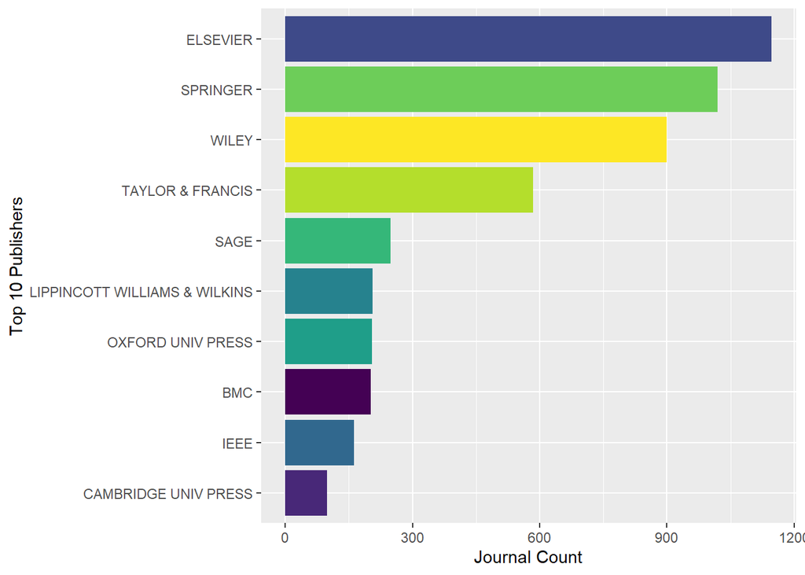

```r
# Flip the plot to avoid overlapping labels.
g_top10 + coord_flip()
```

```r
# Randomly select one journal per top-10 publisher.
## Set seed value for reproducibility.
set.seed(7777)
df_random <- df_clean %>%
  select(`Publisher name`, `Journal title`) %>%
  group_by(`Publisher name`) %>%
  slice_sample(n = 1)

df_top10_random_sample <- df_top10 %>%
  inner_join(df_random) %>%
  rename(Publisher = `Publisher name`, `Number of journal (English-only)` = n, `Target journal` = `Journal title`)
df_top10_random_sample
```

| Publisher | Number of journal (English-only) | Target journal |
| --- | --- | --- |
| ELSEVIER | 1147 | MICROELECTRONICS RELIABILITY |
| SPRINGER | 1019 | EUROPEAN JOURNAL OF TRAUMA AND EMERGENCY SURGERY |
| WILEY | 899 | GENESIS |
| TAYLOR & FRANCIS | 585 | APPLIED ARTIFICIAL INTELLIGENCE |
| SAGE | 248 | NURSING SCIENCE QUARTERLY |
| LIPPINCOTT WILLIAMS & WILKINS | 206 | AMERICAN JOURNAL OF SURGICAL PATHOLOGY |
| OXFORD UNIV PRESS | 204 | QUARTERLY JOURNAL OF MECHANICS AND APPLIED MATHEMATICS |
| BMC | 202 | ALZHEIMERS RESEARCH & THERAPY |
| IEEE | 162 | IEEE TRANSACTIONS ON SUSTAINABLE ENERGY |
| CAMBRIDGE UNIV PRESS | 98 | ANZIAM JOURNAL |

```r
# Save randomly selected 10 journals in csv.
readr::write_csv(df_top10_random_sample, "csv/randomly_selected_10_journals.csv")
```

```r
signup_submission <- pick("csv/signup_submission.csv")
signup_submission %>%
  filter(!is.na(Impact)) %>%
  count(Procedure, Impact, sort = TRUE) %>%
  group_by(Procedure) %>%
  mutate(`%` = paste0(round(100 * n / sum(n)), "%")) %>%
  ungroup() %>%
  arrange(Procedure) %>%
  readr::write_csv("csv/Table2_common_issue.csv")
```

[output not shown]

[output cut: 58 more lines]

[output not shown]

```
## VI cannot process ggplot objects with flipped or non-Cartesian coordinates
```

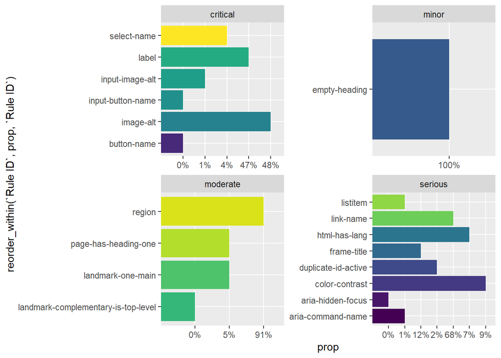

```r
g_signup_issue <- signup_submission %>%
  filter(!is.na(Impact)) %>%
  filter(Procedure == "signup") %>%
  count(Impact, `Rule ID`, sort = TRUE) %>%
  group_by(Impact) %>%
  mutate(prop = paste0(round(100 * n / sum(n)), "%")) %>%
  ungroup() %>%
  arrange(Impact) %>%
  ggplot(aes(x = reorder_within(`Rule ID`, prop, `Rule ID`), y = prop, fill = `Rule ID`)) +
  geom_col(show.legend = FALSE) +
  coord_flip() +
  facet_wrap(~Impact, scales = "free") +
  scale_x_reordered() +
  # scale_y_continuous(labels = scales::percent_format(accuracy = 0.1)) +
  scale_fill_viridis_d()

g_signup_issue
```

```r
alt_signup_issue <- signup_submission %>%
  filter(!is.na(Impact)) %>%
  filter(Procedure == "signup") %>%
  count(Impact, `Rule ID`, sort = TRUE) %>%
  group_by(Impact) %>%
  mutate(prop = paste0(round(100 * n / sum(n)), "%")) %>%
  ungroup() %>%
  arrange(Impact) %>%
  ggplot(aes(x = reorder_within(`Rule ID`, prop, `Rule ID`), y = prop, fill = `Rule ID`)) +
  geom_col(show.legend = FALSE) +
  # coord_flip() +
  facet_wrap(~Impact, scales = "free") +
  scale_x_reordered() +
  # scale_y_continuous(labels = scales::percent_format(accuracy = 0.1)) +
  scale_fill_viridis_d()

alt <- make_alt(alt_signup_issue)
```

[output not shown]

```r
fileConn <- file("fig1_alt.txt")
writeLines(alt, fileConn)
close(fileConn)
```

[output not shown]

[output cut: 82 more lines]

[output not shown]

```
## VI cannot process ggplot objects with flipped or non-Cartesian coordinates
```

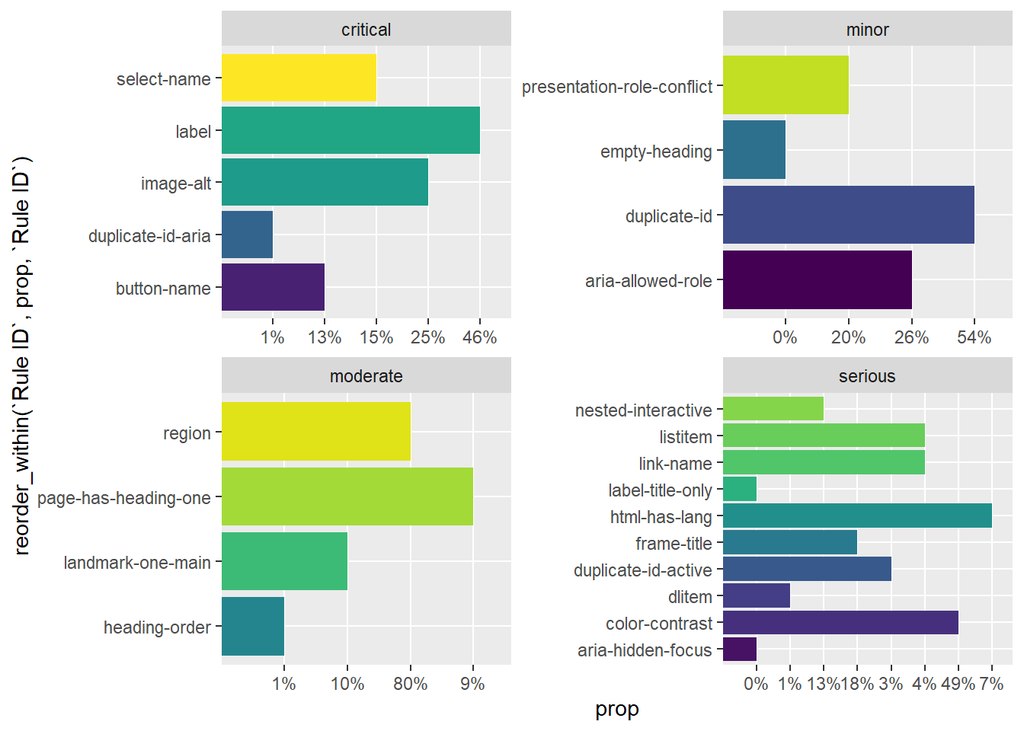

```r
g_submission_issue <- signup_submission %>%
  filter(!is.na(Impact)) %>%
  filter(Procedure == "submission") %>%
  count(Impact, `Rule ID`, sort = TRUE) %>%
  group_by(Impact) %>%
  mutate(prop = paste0(round(100 * n / sum(n)), "%")) %>%
  ungroup() %>%
  arrange(Impact) %>%
  ggplot(aes(x = reorder_within(`Rule ID`, prop, `Rule ID`), y = prop, fill = `Rule ID`)) +
  geom_col(show.legend = FALSE) +
  coord_flip() +
  facet_wrap(~Impact, scales = "free") +
  scale_x_reordered() +
  # scale_y_continuous(labels = scales::percent_format(accuracy = 0.1)) +
  scale_fill_viridis_d()

g_submission_issue
```

```r
alt_submission_issue <- signup_submission %>%
  filter(!is.na(Impact)) %>%
  filter(Procedure == "submission") %>%
  count(Impact, `Rule ID`, sort = TRUE) %>%
  group_by(Impact) %>%
  mutate(prop = paste0(round(100 * n / sum(n)), "%")) %>%
  ungroup() %>%
  arrange(Impact) %>%
  ggplot(aes(x = reorder_within(`Rule ID`, prop, `Rule ID`), y = prop, fill = `Rule ID`)) +
  geom_col(show.legend = FALSE) +
  # coord_flip() +
  facet_wrap(~Impact, scales = "free") +
  scale_x_reordered() +
  # scale_y_continuous(labels = scales::percent_format(accuracy = 0.1)) +
  scale_fill_viridis_d()

alt <- make_alt(alt_submission_issue)
```

[output not shown]

[output cut: 13 more lines]

[output not shown]

```r
fileConn <- file("fig2_alt.txt")
writeLines(alt, fileConn)
close(fileConn)
```

# Research Question

Is there a statistically significant relationship between journal system and accessibility impact?

## Hypotheses

*H0*: There is no statistically significant relationship between journal system and accessibility impact.

In other words, journal system and accessibility impact are independent of one another.

*Ha*: There is a statistically significant relationship between journal system and accessibility impact.

In other words, journal system and accessibility impact are not independent.

# Data Analysis

We used R [Version 4.2.1; R Core Team] for all our analyses.

To examine the research question, Pearson’s Chi-squared test will be conducted. The Chi-squared is an appropriate statistical test when the purpose of the research is to examine the relationship between two nominal level variables (Agresti).

To evaluate significance of the results, the calculated Chi-squared coefficient ($\chi^2$) and the critical value coefficient will be compared. When the calculated value is larger than the critical value, with alpha of .05, the null hypothesis will be rejected (suggesting a significant relationship).

In order to determine the degrees of freedom for a Chi-squared, it is necessary to use the following equation:

$$df = (r - 1)(c - 1)$$

The r value equals the number of rows, and the c value equals the number of columns. In order for a Chi-squared to run correctly, several conditions and assumptions must be met. The data must be random samples of multinomial mutually exclusive distribution and the expected frequencies should not be too small. As a traditional precautionary measure in Chi-squared examination, the expected frequencies below five should not account for more than 20% of the cells, and there should be no cells with an expected frequency of less than one. If the expected cell frequencies are less than 5, Yates continuity correction will be used to test for significance (if it is a $2\times{}2$ Chi squared), as it is a more conservative statistic.

# Results

The following is the results of the interpretation.

There is an association between journal system and accessibility impact ($\chi^2[6, n = 4815] = 952.25$, $p < .001$).

```r
chiTable
```

| statistic | p.value | parameter | method |
| --- | --- | --- | --- |
| 952.2 | 0 | 6 | Pearson’s Chi-squared test |

# Visualization

## Correspondence Analysis

Figure 1 illustrates the corresppondence analysis plot of journal system and accessibility impact using “ca” package in R (Greenacre and Nenadic).

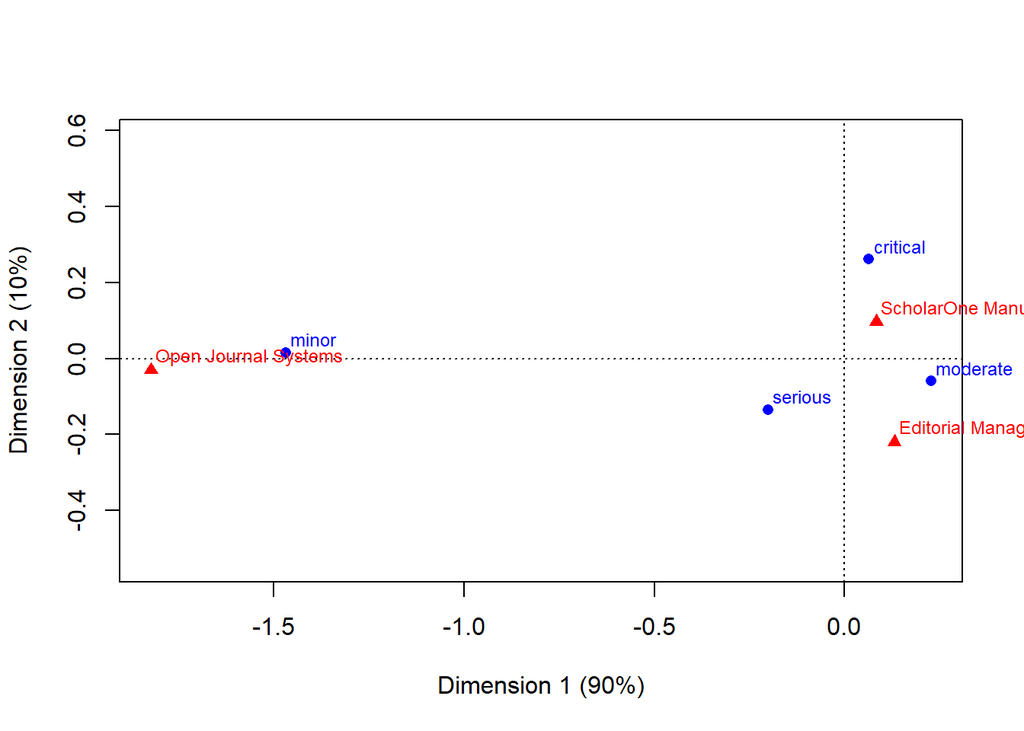

Figure 1: Correspondence analysis plot.

## Heat Map

### Basic Heat Map Using Cross-Count Frequency

Figure 2 illustrates the the frequency heatmap acrossing journal system and accessibility impact.

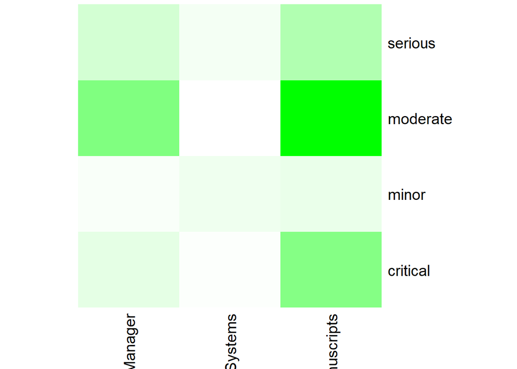

Figure 2: Frequency heat map visualization.

### Heat Map Using Marginal Row Table

Figure 3 illustrates the heat map based on marginal rows.

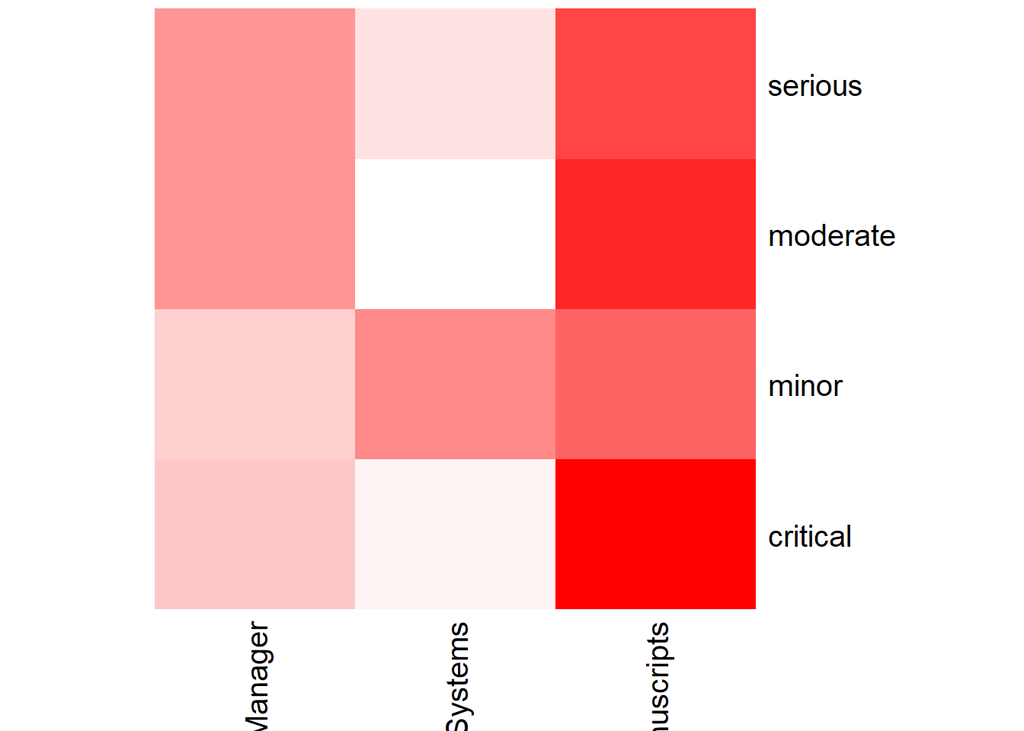

Figure 3: Heat map visualization based on row margins.

### Heat Map Using Marginal Column Table (recommended)

Figure 4 illustrates the heat map based on marginal columns.

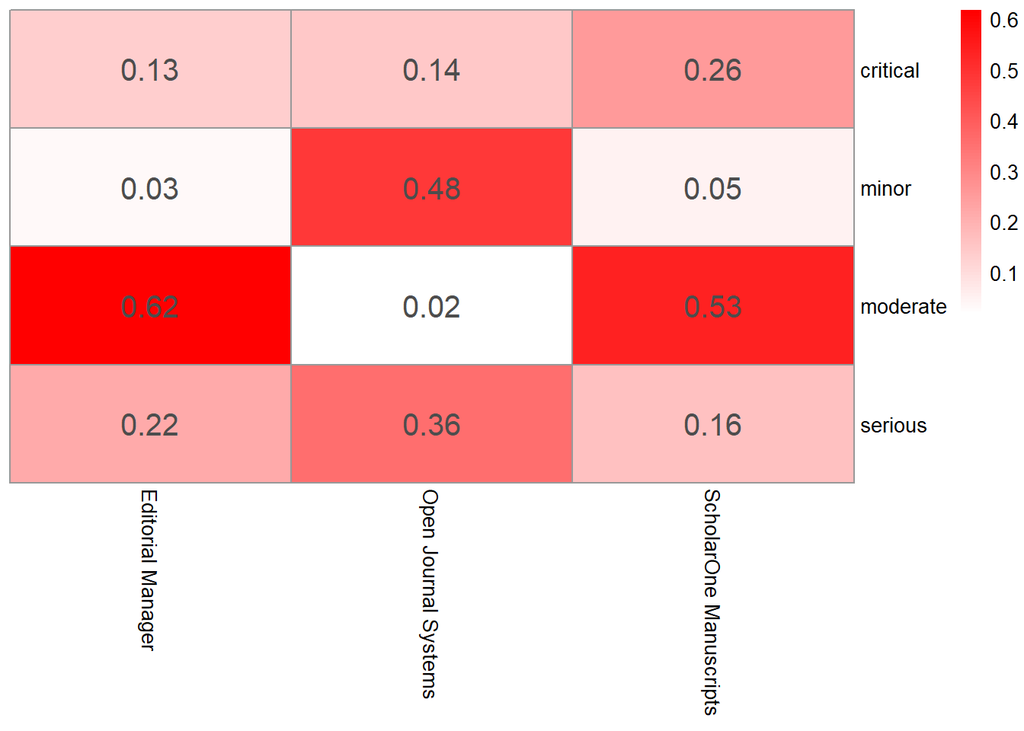

Figure 4: Heat map visualization based on column margins.

```r
detach(data)
```

```r
a11y_impact_per_system <- signup_submission %>%
  filter(!is.na(Impact)) %>%
  count(System, Impact, sort = TRUE) %>%
  group_by(System) %>%
  mutate(`%` = paste0(round(100 * n / sum(n)), "%")) %>%
  ungroup() %>%
  arrange(System) %>%
  select(-n)

a11y_impact_per_system
```

| System | Impact | % |
| --- | --- | --- |
| Editorial Manager | moderate | 62% |
| Editorial Manager | serious | 22% |
| Editorial Manager | critical | 13% |
| Editorial Manager | minor | 3% |
| Open Journal Systems | minor | 48% |
| Open Journal Systems | serious | 36% |
| Open Journal Systems | critical | 14% |
| Open Journal Systems | moderate | 2% |
| ScholarOne Manuscripts | moderate | 53% |
| ScholarOne Manuscripts | critical | 26% |
| ScholarOne Manuscripts | serious | 16% |
| ScholarOne Manuscripts | minor | 5% |

```r
readr::write_csv(a11y_impact_per_system, "csv/Table3_a11y_impact_per_system.csv")
```

# References

Agresti, Alan. *An Introduction to Categorical Data Analysis*. 2nd ed., Wiley-Interscience, 2007.

Greenacre, Michael, and Oleg Nenadic. *Ca: Simple, Multiple and Joint Correspondence Analysis*. 2020, http://www.carme-n.org/.

R Core Team. *R: A Language and Environment for Statistical Computing*. R Foundation for Statistical Computing, 2021, https://www.R-project.org/.